# Warmup

```r
knitr::opts_chunk$set(echo = TRUE, eval = TRUE)
library(readr)
library(caret)
library(ggplot2)
library(dplyr)

# Load the wine quality data from a CSV file
wine_data <- read.csv("winequality-red.csv", sep= ";")

# For reproducibility
set.seed(123)

# Split the data into a training set and a testing set
train_index <- createDataPartition(wine_data$quality, p = 0.7, list = FALSE)
train_data <- wine_data[train_index, ]
test_data <- wine_data[-train_index, ]
```

# Linear regression

```r
# Build linear regression
model <- lm(quality ~ ., data = train_data)

# Evaluate the performance of the model
prediction_train <- predict(model, newdata = train_data)
rmse_train <- sqrt(mean((train_data$quality - prediction_train)^2))


prediction_test <- predict(model, newdata = test_data)
rmse_test <- sqrt(mean((test_data$quality - prediction_test)^2))

print(paste("Prediction Quality for train set RMSE =", rmse_train))
```

```
[1] "Prediction Quality for train set RMSE = 0.640688208979915"
```

```r
print(paste("Prediction Quality for test set RMSE =", rmse_test))
```

```
[1] "Prediction Quality for test set RMSE = 0.65989109917522"
```

I used linear regression to predict the quality of red wine. After fitting the model, I tried to predict and compare results for both train and test sets to avoid the over fitting. The following plot shows the actual vs predicted Wine Quality for test set.

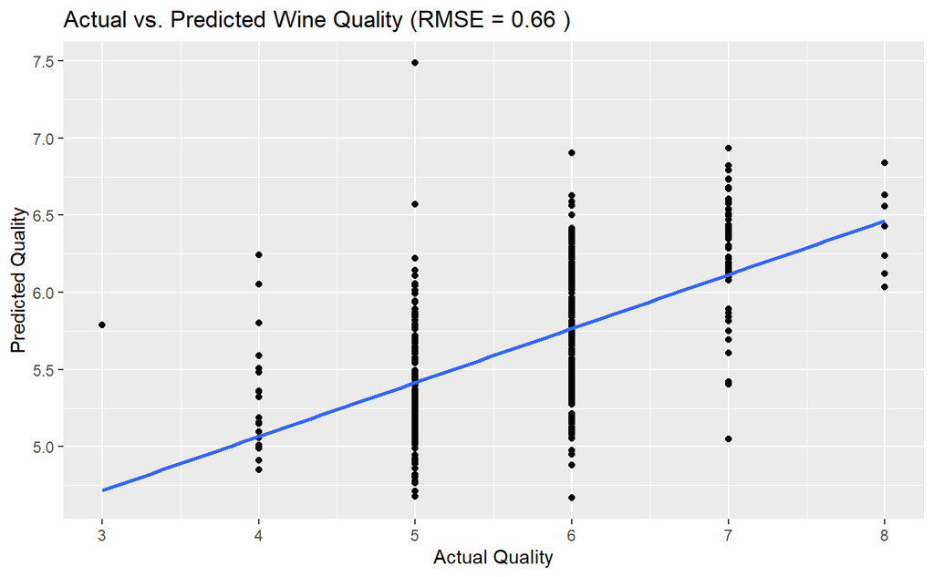

```r
# Plot the Actual and Predicted Wine Quality for test dataset
ggplot(data = test_data, aes(x = quality, y = prediction_test)) +
  geom_point() +
  geom_smooth(method = "lm", se = FALSE) +
  labs(x = "Actual Quality", y = "Predicted Quality") +
  ggtitle(paste("Actual vs. Predicted Wine Quality (RMSE =", round(rmse_test, 2), ")"))
```

## 10-fold cross-validation

Here, I used 10-fold CV for the problem above to compare the results which are close to each other.

```r
# Perform 10-fold cross-validation
num_folds <- 10
cv_results <- train(quality ~ ., data = train_data, method = "lm", trControl = trainControl(method = "cv", number = num_folds))
cv_rmse <- cv_results$results$RMSE

prediction_test_cv <- predict(cv_results, newdata = test_data)
rmse_test_cv <- sqrt(mean((test_data$quality - prediction_test_cv)^2))

print(paste("Model Performance using 10-fold cross-validation RMSE =", cv_rmse))
```

```
[1] "Model Performance using 10-fold cross-validation RMSE = 0.64769086002939"
```

```r
print(paste("Prediction Quality for test set using 10-fold cross-validation RMSE =", rmse_test_cv))
```

```
[1] "Prediction Quality for test set using 10-fold cross-validation RMSE = 0.65989109917522"
```

# Classification

For classification problem, I am using a threshold to classify the wine quality as “high” and “low” which would turn the problem to binary classification. Knn would then be used to train the model and accuracy of the model be evaluated by confusion matrix for both training and testing sets.

```r
# Define a quality threshold to classify as "high" or "low" quality
quality_threshold <- 6

# Create a binary classification target variable
train_data$class <- ifelse(train_data$quality >= quality_threshold, "High Quality", "Low Quality")
test_data$class <- ifelse(test_data$quality >= quality_threshold, "High Quality", "Low Quality")

# Create a classification model (random forest)
c_model <- train(class ~ ., data = train_data, method = "knn")

# Evaluate the classification model for train set
predictions_train <- predict(c_model, newdata = train_data)
confusion_matrix_train <- confusionMatrix(as.factor(train_data$class), as.factor(predictions_train))
print(paste("confusion matrix for train data"))
```

```
[1] "confusion matrix for train data"
```

```r
print(confusion_matrix_train)
```

```
Confusion Matrix and Statistics

              Reference
Prediction     High Quality Low Quality
  High Quality          482         117
  Low Quality           100         421

               Accuracy : 0.8062
                 95% CI : (0.7819, 0.829)
    No Information Rate : 0.5196
    P-Value [Acc > NIR] : <2e-16

                  Kappa : 0.6114

 Mcnemar's Test P-Value : 0.2774

            Sensitivity : 0.8282
            Specificity : 0.7825
         Pos Pred Value : 0.8047
         Neg Pred Value : 0.8081
             Prevalence : 0.5196
         Detection Rate : 0.4304
   Detection Prevalence : 0.5348
      Balanced Accuracy : 0.8054

       'Positive' Class : High Quality
```

```r
# Evaluate the classification model for test set
predictions_test <- predict(c_model, newdata = test_data)
confusion_matrix_test <- confusionMatrix(as.factor(test_data$class), as.factor(predictions_test))
print(paste("confusion matrix for test data"))
```

```
[1] "confusion matrix for test data"
```

```r
print(confusion_matrix_test)
```

```
Confusion Matrix and Statistics

              Reference
Prediction     High Quality Low Quality
  High Quality          197          59
  Low Quality            65         158

               Accuracy : 0.7411
                 95% CI : (0.6994, 0.7798)
    No Information Rate : 0.547
    P-Value [Acc > NIR] : <2e-16

                  Kappa : 0.4789

 Mcnemar's Test P-Value : 0.6534

            Sensitivity : 0.7519
            Specificity : 0.7281
         Pos Pred Value : 0.7695
         Neg Pred Value : 0.7085
             Prevalence : 0.5470
         Detection Rate : 0.4113
   Detection Prevalence : 0.5344
      Balanced Accuracy : 0.7400

       'Positive' Class : High Quality
```

Based on the results, accuracy of predictions using train and test sets are slightly different. The predictions using train set has better accuracy with 0.80 in comparison to the test set with accuracy of 0.74. Seems that model is over fitted here, however, we can investigate more about the model by changing the quality threshold (quality_threshold <- 6) and split size of the data (p = 0.7).